# Определение суммарного коэффициента сопротивления по значению пропускной способности $K_V$

При проведении гидравлических расчётов для вычисления потерь полного давления в каком либо элементе трубопровода необходимо иметь значение его суммарного коэффициента сопротивления, который равен сумме значений коэффициента сопротивления трения и коэффициента местного сопротивления.

В справочных данных по запорной арматуре в качестве параметра, характеризующего гидравлическое сопротивление, приводится значение пропускной способности $K_V$.

Пропускная способность элемента трубопровода $K_V$ - значение, равное расходу жидкости, $м^3/ч$, плотностью 1000 $кг/м^3$, протекающей через элемент трубопровода при перепаде давления на нём 0,1 МПа.

Потери давления через суммарный коэффициент сопротивления находятся по формуле:

$$\Delta p = \zeta_{сум} \frac{\rho w^2}{2}$$

отсюда $$\zeta_{сум} = \frac{2 \Delta p}{\rho w^2} \ \ \ \ \ \ (1)$$

где $\zeta_{сум}$ - искомый суммарный коэффициент сопротивления, $\Delta p = 10^5$ Па (см. определение пропускной способности выше) - потери давления, $\rho=1000$ $кг/м^3$ - плотность среды, $w$ - скорость движения среды плотностью 1000 $кг/м^3$ внутри трубопровода на котором установлен рассматриваемый элемент, $м/с$, при объёмном расходе $K_V$.

$$w = Q / F,$$

где $Q$ - объёмный расход среды, $м^3/c$, $F$ - площадь внутреннего сечения трубопровода на котором установлен рассматриваемый элемент, $м^2$.  
$K_V$ - это объёмный расход в $м^3/ч$, тогда $Q = K_V/3600$. Подставив выведенные выше выражения в формулу (1), получим:

$$\zeta_{сум} = \frac{2 \cdot 10^5}{1000}\left(\frac{3600 \cdot F}{K_V}\right)^2$$

```python
2e5 / 1000 * 3600**2 / 1e6
```

```
2592.0
```

В итоге искомое выражение принимает вид:

$$\zeta_{сум} = 2592\cdot 10^6 \left(\frac{ F}{K_V}\right)^2$$

где $$F = \frac{\pi(D-2h)^2}{4}\cdot 10^{-6},$$

где $D$ - внешний диаметр трубопровода, мм; $h$ - толщина стенки трубопровода, мм. Например, для трубопровода 108х5: внешний диаметр 108 мм, толщина стенки 5 мм.

## Вывод формулы с помощью символьных вычислений

https://habr.com/ru/post/423731/

```python
from sympy import *
```

Обозначения переменных:  
rc - суммарный коэффициент сопротивления $\zeta_{сум}$ (rc - сокращённо от resistance coefficient)  
dp - потери давления $\Delta p$, Па  
rho - плотность $\rho$, $кг/м^3$  
Q - расход, $м^3/с$  
Kv - пропускная способность $K_V$, $м^3/ч$  
w - скорость $w$, $м/с$  
F - площадь внутреннего сечения трубопровода, $м^2$  
D - внешний диаметр трубы, $мм$  
h - толщина стенки трубы, $мм$

```python
#Создаём символьные переменные
Q, Kv, w, F = symbols('Q K_V w F')
D, h, pi = symbols('D h pi')
```

```python
dp = 1e5 #из определения Kv, Па
rho = 1e3 #из определения Kv, кг/м3
```

```python
F = pi * (D - 2 * h) ** 2 / 4 * 1e-6
F
```

$\displaystyle 2.5 \cdot 10^{-7} \pi \left(D - 2 h\right)^{2}$

```python
Q = Kv / 3600
Q
```

$\displaystyle \frac{K_{V}}{3600}$

```python
w = Q / F
w
```

$\displaystyle \frac{1111.11111111111 K_{V}}{\pi \left(D - 2 h\right)^{2}}$

```python
#Записываем формулу (1)
rc = 2 * dp / (rho * w **2)
#и выводим окончательный результат
rc
```

$\displaystyle \frac{0.000162 \pi^{2} \left(D - 2 h\right)^{4}}{K_{V}^{2}}$

```python
#Присваиваем pi числовое значение и обновляем выражения, где фигурировало pi
import math #возьмём значение pi из модуля math
pi = math.pi
F = pi * (D - 2 * h) ** 2 / 4 * 1e-6
F
```

$\displaystyle 7.85398163397448 \cdot 10^{-7} \left(D - 2 h\right)^{2}$

```python
w = Q / F
w
```

$\displaystyle \frac{353.677651315323 K_{V}}{\left(D - 2 h\right)^{2}}$

```python
#формула для вычисления суммарного коэффициента сопротивления по Kv
rc = 2 * dp / (rho * w **2)
```

### Для D и h, выраженных в миллиметрах

```python
rc
```

$\displaystyle \frac{0.00159887591297648 \left(D - 2 h\right)^{4}}{K_{V}^{2}}$

### Для D и h, выраженных в метрах

```python
rc * 1e3 ** 4
```

$\displaystyle \frac{1598875912.97648 \left(D - 2 h\right)^{4}}{K_{V}^{2}}$

## Проведение расчётов с помощью символьных вычислений

```python
#Можно найти значение коэффициена сопротивления для конкретных значений Kv, D, h
rc.subs([(D, 108), (h, 5), (Kv, 100)])
```

$\displaystyle 14.7475223392043$

```python
#Зависимость коэффициена сопротивления от Kv для трубопровода 108х5
rc_Kv = rc.subs([(D, 108), (h,5)])
rc_Kv
```

$\displaystyle \frac{147475.223392043}{K_{V}^{2}}$

```python
Kvs = list(range(10, 101, 5))
rcs = []
for kv in Kvs:
    rcs.append(rc_Kv.subs(Kv, kv))
```

```python
Kvs #м3/ч
```

```
[10, 15, 20, 25, 30, 35, 40, 45, 50, 55, 60, 65, 70, 75, 80, 85, 90, 95, 100]
```

```python
rcs
```

```
[1474.75223392043,
 655.445437297970,
 368.688058480108,
 235.960357427269,
 163.861359324492,
 120.387937462892,
 92.1720146200270,
 72.8272708108856,
 58.9900893568173,
 48.7521399643118,
 40.9653398311231,
 34.9053783176434,
 30.0969843657231,
 26.2178174919188,
 23.0430036550068,
 20.4117956251963,
 18.2068177027214,
 16.3407449741876,
 14.7475223392043]
```

```python
#Создадим таблицу
import pandas as pd
```

```python
table = pd.DataFrame({'Kv, м3/ч': Kvs, '$\zeta_{сум}$': rcs})
table
```

|  | Kv, м3/ч | $\zeta_{сум}$ |
| --- | --- | --- |
| 0 | 10 | 1474.75223392043 |
| 1 | 15 | 655.445437297970 |
| 2 | 20 | 368.688058480108 |
| 3 | 25 | 235.960357427269 |
| 4 | 30 | 163.861359324492 |
| 5 | 35 | 120.387937462892 |
| 6 | 40 | 92.1720146200270 |
| 7 | 45 | 72.8272708108856 |
| 8 | 50 | 58.9900893568173 |
| 9 | 55 | 48.7521399643118 |
| 10 | 60 | 40.9653398311231 |
| 11 | 65 | 34.9053783176434 |
| 12 | 70 | 30.0969843657231 |
| 13 | 75 | 26.2178174919188 |
| 14 | 80 | 23.0430036550068 |
| 15 | 85 | 20.4117956251963 |
| 16 | 90 | 18.2068177027214 |
| 17 | 95 | 16.3407449741876 |
| 18 | 100 | 14.7475223392043 |

```python
#Сохранение результатов расчёта в csv-файл:
#table.to_csv('Коэффициент сопротивления от Kv.csv', sep = ';')
#Сохранение результатов расчёта в html-файл:
#table.to_html('Коэффициент сопротивления от Kv.html')
```

```python
#Нарисуем график
import matplotlib.pyplot as plt
```

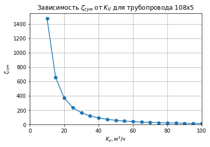

```python
plt.plot(Kvs, rcs, 'o-')
plt.title('Зависимость $\zeta_{сум}$ от $K_V$ для трубопровода 108х5' )
plt.xlabel('$K_V, м^3/ч$'); plt.ylabel('$\zeta_{сум}$')
plt.xlim (0,100), plt.ylim (0,)
plt.grid()
```

[Инженерные расчёты на Python](https://zen.yandex.ru/id/5f33dcd5554adc5b33aaee83), С.В. Медведев, 2020  
[Использование Python и Jupyter Notebook для инженерных расчётов](https://medsv.github.io/), С.В. Медведев, 2020